# Outcome Weights Application

Neural Networks as Approximate Smoothers

Aaron Sennhenn

This notebook produces the resutts and figure of Chapter 5. It adapts the 401(k) application notebook of Knaus (2024) and thus keeps largely keeps it structure and comments. It utilizes functions of the OutcomeWeights package by replacing the nuissance estimator by the ridge smoother estimator considered in the thesis.

First, load packages and set the seed:

```r
set.seed(42)
if (!require("OutcomeWeights")) install.packages("OutcomeWeights", dependencies = TRUE); library(OutcomeWeights)
if (!require("hdm")) install.packages("hdm", dependencies = TRUE); library(hdm)
if (!require("grf")) install.packages("grf", dependencies = TRUE); library(grf)
if (!require("cobalt")) install.packages("cobalt", dependencies = TRUE); library(cobalt)
if (!require("tidyverse")) install.packages("tidyverse", dependencies = TRUE); library(tidyverse)
if (!require("viridis")) install.packages("viridis", dependencies = TRUE); library(viridis)
if (!require("gridExtra")) install.packages("gridExtra", dependencies = TRUE); library(gridExtra)
if (!require("torch")) install.packages("torch", dependencies = TRUE); library(torch)
```

Load custom neural network OutcomeWeights functions:

```r
source("src/application/functions_ridge_application.R")
source("src/application/NuPa_neural_net.R")
source("src/application/dml_with_smoother_neural_net.R")
```

Next, load the data. Here we use the 401(k) data of the `hdm` package.

```r
data(pension) # Find variable description if you type ?pension in console

# Treatment
D = pension$p401
# Instrument
Z = pension$e401
# Outcome
Y = pension$net_tfa
# Controls
X = model.matrix(~ 0 + age + db + educ + fsize + hown + inc + male + marr + pira + twoearn, data = pension)
var_nm = c("Age","Benefit pension","Education","Family size","Home owner","Income","Male","Married","IRA","Two earners")
colnames(X) = var_nm
```

## 1. Run Double ML

### 2-folds

Run double ML also with 2-fold cross-fitting:

```r
# 2 folds
set.seed(42)
dml_2f = dml_with_smoother_neural_net(Y,D,X,Z,
                           n_cf_folds = 2, estimators = c("PLR","PLR_IV"))
results_dml_2f = summary(dml_2f)
```

```
##        Estimate      SE      t         p
## PLR     11601.1  1314.4 8.8263 < 2.2e-16 ***
## PLR-IV  12091.7  1994.2 6.0635 1.381e-09 ***
## ---
## Signif. codes:  0 '***' 0.001 '**' 0.01 '*' 0.05 '.' 0.1 ' ' 1
```

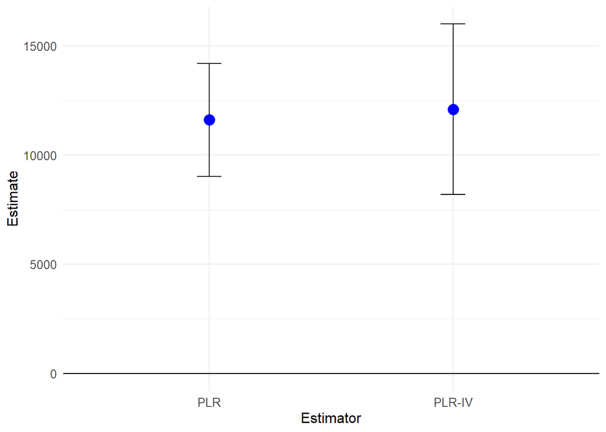

```r
plot(dml_2f)
```

Use the `get_outcome_weights()` method to extract the outcome weights. By design the ridge smoother representation will hold exactly.

```r
omega_dml_2f = get_outcome_weights(dml_2f)
cat("ω'Y replicates point etimates?",
    all.equal(as.numeric(omega_dml_2f$omega %*% Y),
      as.numeric(results_dml_2f[,1])
    ))
```

```
## ω'Y replicates point etimates? TRUE
```

### 5-fold

Run double ML also with 5-fold cross-fitting:

```r
# 5 folds
set.seed(42)
dml_5f = dml_with_smoother_neural_net(Y,D,X,Z,
                           n_cf_folds = 5, estimators = c("PLR","PLR_IV"))
results_dml_5f = summary(dml_5f)
```

```
##        Estimate      SE      t         p
## PLR     12900.2  1473.5 8.7547 < 2.2e-16 ***
## PLR-IV  13286.7  1942.4 6.8403 8.371e-12 ***
## ---
## Signif. codes:  0 '***' 0.001 '**' 0.01 '*' 0.05 '.' 0.1 ' ' 1
```

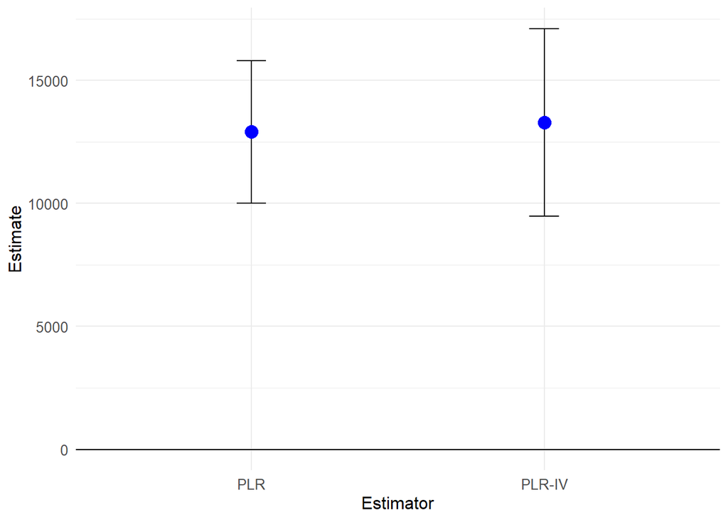

```r
plot(dml_5f)
```

```r
omega_dml_5f = get_outcome_weights(dml_5f)
cat("ω'Y replicates point etimates?",
    all.equal(as.numeric(omega_dml_5f$omega %*% Y),
      as.numeric(results_dml_5f[,1])
    ))
```

```
## ω'Y replicates point etimates? TRUE
```

## 2. Check covariate balancing

Use the infrastructure of the `cobalt` package to plot Standardized Mean Differences where we need to flip the sign of the untreated outcome weights to make them compatible with the package framework. This is achieved by multiplying the outcome weights by $2 \times D-1$.

```r
threshold = 0.1

create_love_plot = function(title, index) {
  love.plot(
    D ~ X,
    weights = list(
      "2-fold" = omega_dml_2f$omega[index, ] * (2*D-1),
      "5-fold" = omega_dml_5f$omega[index, ] * (2*D-1)
    ),
    position = "bottom",
    title = title,
    thresholds = c(m = threshold),
    var.order = "unadjusted",
    binary = "std",
    abs = TRUE,
    line = TRUE,
    colors = viridis(3), # color-blind-friendly
    shapes = c("circle", "triangle", "diamond")
  )
}

# Create plot that end up in Chapter 5
love_plot_plr = create_love_plot("PLR", 1)
```

```
## Note: `s.d.denom` not specified; assuming "pooled".
```

```r
love_plot_plriv = create_love_plot("PLR-IV", 2)
```

```
## Note: `s.d.denom` not specified; assuming "pooled".
```

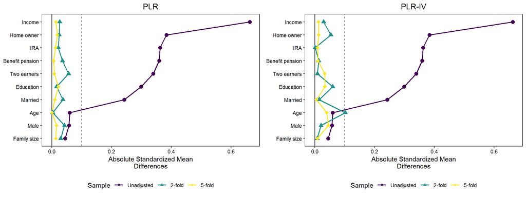

```r
loveplot = grid.arrange(love_plot_plr, love_plot_plriv, ncol = 2)
```